# Starwars Character Report

January 11, 2023 8 minute read

[figure not shown]

## Starwars Data

Starwars API의 데이터는 스타워즈에 등장하는 캐릭터들의 특징을 정리해 놓은 데이터입니다.

- Data : https://dplyr.tidyverse.org/reference/starwars.html

## Purpose & Contents

해당 Report는 스타워즈 캐릭터에 대한 분석입니다. 분석 내용은 아래와 같습니다.

- 스타원즈 캐릭터 성별 비율
- 성별에 따른 캐릭터 신장의 분포
- 가장 무거운 캐릭터와 가장 가벼운 캐릭터
- 스타워즈 캐릭터의 키/몸무게의 상관관계 분석

## Data

**columns**

- name: 캐릭터 이름
- height: 키
- mass: 몸무게
- hair_color: 머리카락 색
- skin_color: 피부색
- eye_color: 눈동자 색
- birth_year: 생년
- sex: 생물학적 성별
- gender: 사회적 성별
- homeworld: 고향
- species: 종

**Data Summary**

- 총 데이터 개수: 957
- 총 결측치 수: 105 = 전체 데이터의 10.97%
- 스타워즈에 등장하는 등장인물 수: 87
- 스타워즈에 등장하는 종족 수: 37

## Conclusion

- 스타워즈 캐릭터의 성별 비율

[figure not shown]

  Gender/Sex 비율

```
 : 남성/남성 gender를 가진 캐릭터가 80% 가량을 차지하며, 로봇(Robot)과 자웅동체(hermaphoroditic)가 존재한다.
```

- 성별에 따른 캐릭터 신장의 분포

[figure not shown]

Height distribution

: 남성 캐릭터의 키가 대체로 여성보다 크며, 로봇은 그보다 키가 작다.

- 가장 무거운 캐릭터와 가장 가벼운 캐릭터

[figure not shown]

High-weight races

```
:   몸무게 상위 10개 종족은 ['Hutt'], ['Kaleesh'], ['Wookiee'], ['Trandoshan'], ['Besalisk'], ['Neimodian'], ['Nautolan'], ['Mon Calamari'], ['Cerean'], ['pau'an'] 이다
```

[figure not shown]

Weight Graph by Race

[output not shown]

- 스타워즈 캐릭터의 키와 몸무게는 상관관계

[figure not shown]

  Weight-Height correlation

  : 키와 몸무게는 일반적으로 상관관계를 가진다. 인간과 다른 행성에 사는 종족이지만, 키와 몸무게는 대체로 비례 관계를 보인다.

## Code

```python
#한글 폰트 설정
!sudo apt-get install -y fonts-nanum
!sudo fc-cache -fv
!rm ~/.cache/matplotlib -rf
```

[output not shown]

```python
#기본 패키지
import math
import numpy as np
import pandas as pd
import seaborn as sns
import matplotlib.pyplot as plt
plt.rc('font', family='NanumBarunGothic') #한글 폰트 가져오기

plt.style.use('seaborn') #그래프 기본 설정
sns.set(font_scale=1)

import warnings
warnings.simplefilter(action='ignore', category=FutureWarning)
```

```python
#구글 드라이브 마운트
from google.colab import drive
drive.mount('/content/drive')
```

```python
from google.colab import drive
drive.mount('/content/drive')
```

```python
#데이터 불러오기
#csv 데이터 파일
sw = pd.read_csv('/content/drive/MyDrive/Colab Notebooks/데이터 분석 실습/Starwars/Starwars.csv')
```

<컬럼 설명>

- name: 캐릭터 이름
- height: 키
- mass: 몸무게
- hair_color: 머리카락 색
- skin_color: 피부색
- eye_color: 눈동자 색
- birth_year: 생년
- sex: 생물학적 성별
- gender: 사회적 성별
- homeworld: 고향
- species: 종

```python
#데이터 내용 요약
print("총 데이터 개수: ", sw.shape[0]*sw.shape[1])
print("총 결측치 수: {} = 전체 데이터의 {:.2f}% ".format(sw.isnull().sum().sum(), (sw.isnull().sum().sum()*100)/(sw.shape[0]*sw.shape[1])))
print("스타워즈에 등장하는 등장인물 수: ", sw['name'].nunique())
print("스타워즈에 등장하는 종족 수: ", sw['species'].nunique())
```

```
총 데이터 개수:  957
총 결측치 수: 105 = 전체 데이터의 10.97%
스타워즈에 등장하는 등장인물 수:  87
스타워즈에 등장하는 종족 수:  37
```

## 2.분석 내용

- 스타워즈 캐릭터의 성별 비율
- 성별에 따른 캐릭터 신장의 분포
- 가장 무거운 캐릭터와 가장 가벼운 캐릭터
- 스타워즈 캐릭터의 키와 몸무게 상관관계

## 3.데이터 전처리

### 3-1.결측치 처리

```python
#NULL이 존재하는 컬럼 확인하기
sw.isnull().any(axis=0)
#height, mass, type, x, y 컬럼에 NaN 존재함
```

```
name          False
height         True
mass           True
hair_color     True
skin_color    False
eye_color     False
birth_year     True
sex            True
gender         True
homeworld      True
species        True
dtype: bool
```

```python
#컬럼별로 NULL 개수 확인
sw.isnull().sum()
```

```
name           0
height         6
mass          28
hair_color     5
skin_color     0
eye_color      0
birth_year    44
sex            4
gender         4
homeworld     10
species        4
dtype: int64
```

```python
#결측치 처리
#hair color, sex, gender, homeworld, species의 경우 개인 특성이므로 다른 값을 넣어주는 것이 의미가 없다
#height, mass에서는 결측치를 0으로 처리
sw['height'].fillna(0, inplace=True)
sw['mass'].fillna(0, inplace=True)
sw.head()
```

|  | name | height | mass | hair_color | skin_color | eye_color | birth_year | sex | gender | homeworld | species |
| --- | --- | --- | --- | --- | --- | --- | --- | --- | --- | --- | --- |
| 0 | Luke Skywalker | 172.0 | 77.0 | blond | fair | blue | 19.0 | male | masculine | Tatooine | Human |
| 1 | C-3PO | 167.0 | 75.0 | NaN | gold | yellow | 112.0 | none | masculine | Tatooine | Droid |
| 2 | R2-D2 | 96.0 | 32.0 | NaN | white, blue | red | 33.0 | none | masculine | Naboo | Droid |
| 3 | Darth Vader | 202.0 | 136.0 | none | white | yellow | 41.9 | male | masculine | Tatooine | Human |
| 4 | Leia Organa | 150.0 | 49.0 | brown | light | brown | 19.0 | female | feminine | Alderaan | Human |

```python
#sex -> (none, NaN)
print(sw[sw['sex'] == 'none'])
print(sw[sw['sex'].isnull()])
```

```
      name  height   mass hair_color   skin_color  eye_color  birth_year  \
1    C-3PO   167.0   75.0        NaN         gold     yellow       112.0
2    R2-D2    96.0   32.0        NaN  white, blue        red        33.0
7    R5-D4    97.0   32.0        NaN   white, red        red         NaN
21   IG-88   200.0  140.0       none        metal        red        15.0
72  R4-P17    96.0    0.0       none  silver, red  red, blue         NaN
84     BB8     0.0    0.0       none         none      black         NaN

     sex     gender homeworld species
1   none  masculine  Tatooine   Droid
2   none  masculine     Naboo   Droid
7   none  masculine  Tatooine   Droid
21  none  masculine       NaN   Droid
72  none   feminine       NaN   Droid
84  none  masculine       NaN   Droid
              name  height  mass hair_color skin_color eye_color  birth_year  \
36        Ric Oli?   183.0   0.0      brown       fair      blue         NaN
39   Quarsh Panaka   183.0   0.0      black       dark     brown        62.0
79       Sly Moore   178.0  48.0       none       pale     white         NaN
85  Captain Phasma     0.0   0.0    unknown    unknown   unknown         NaN

    sex gender homeworld species
36  NaN    NaN     Naboo     NaN
39  NaN    NaN     Naboo     NaN
79  NaN    NaN    Umbara     NaN
85  NaN    NaN       NaN     NaN
```

```python
#if sex = none, then species = Droid
sw['sex'][(sw['sex'] == 'none')] = 'robot'
print('Sex: ', sw['sex'].unique())
```

```
Sex:  ['male' 'robot' 'female' 'hermaphroditic' nan]
```

## 4.EDA & Visualization

### 4-1. 스타워즈 캐릭터의 성별 비율

```python
#스타워즈 캐릭터의 성비(sex, gender)
print(sw['sex'].value_counts())
print(sw['gender'].value_counts())
```

```
male              60
female            16
robot              6
hermaphroditic     1
Name: sex, dtype: int64
masculine    66
feminine     17
Name: gender, dtype: int64
```

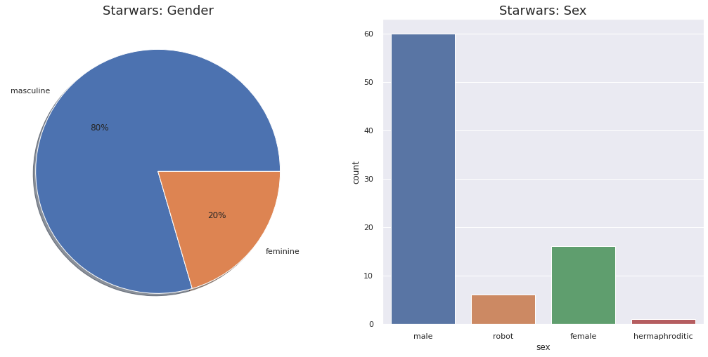

```python
f, ax = plt.subplots(1, 2, figsize=(18, 8))

sw['gender'].value_counts().plot.pie(ax=ax[0], autopct='%1.0f%%', shadow=True)
ax[0].set_title('Starwars: Gender', size=18) #그래프 제목
ax[0].set_ylabel('') #unnecessary y_label

sns.countplot(x='sex', data=sw, ax=ax[1])
ax[1].set_title('Starwars: Sex', size=18) #그래프 제목

plt.show()
```

### 4-2. 스타워즈 캐릭터의 성별에 따른 신장 분포

```python
#스타워즈 캐릭터의 신장
sw['height'].describe()
```

[output not shown]

```python
#skewness and kurtosis 구하기
#Skewness(왜도): 데이터가 정규분포에서 한 쪽으로 치우쳐있는가?
#                -3 < skewness < 3 사이의 값이면 기준에 부합한다
#Kurtosis(첨도): 얼마나 뾰족한가(데이터가 얼마나 평균 근처에 몰려있는가)?
#               : 정규분포의 kurtosis = 0
print("Skewness: %f" % sw['height'].skew())
print("Kurtosis: %f" % sw['height'].kurt())
```

```
Skewness: -1.760878
Kurtosis: 2.927697
```

```python
#자웅동체(hermaphroditic) 캐릭터(Jabba Desilijic Tiure) - 1 instance
sw[sw['sex'] == 'hermaphroditic'].head()
```

|  | name | height | mass | hair_color | skin_color | eye_color | birth_year | sex | gender | homeworld | species |
| --- | --- | --- | --- | --- | --- | --- | --- | --- | --- | --- | --- |
| 15 | Jabba Desilijic Tiure | 175.0 | 1358.0 | NaN | green-tan, brown | orange | 600.0 | hermaphroditic | masculine | Nal Hutta | Hutt |

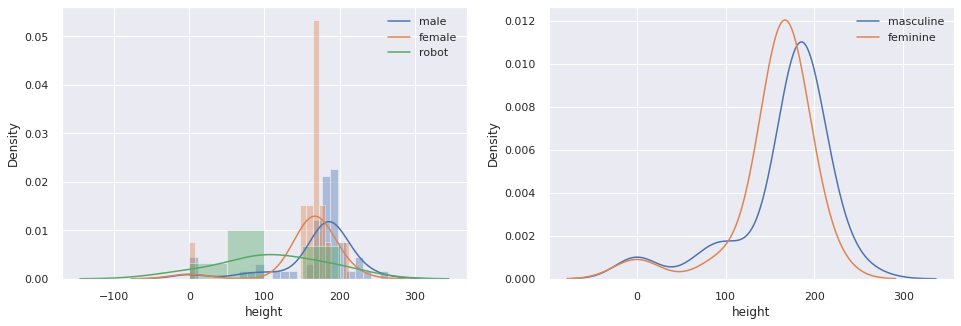

```python
#성별에 따른 스타워즈 캐릭터의 신장 분포 그래프
#자웅동체 캐릭터(Jabba Desilijic Tiure)의 확률 분포 그래프는 존재하지 않음

fig, ax = plt.subplots(1, 2, figsize=(16, 5))

#sns.distplot
sns.distplot(sw[sw['sex'] == 'male']['height'], ax=ax[0])
sns.distplot(sw[sw['sex'] == 'female']['height'], ax=ax[0])
sns.distplot(sw[sw['sex'] == 'robot']['height'], ax=ax[0])
ax[0].legend(['male','female','robot'])

#sns.kdeplot
sns.kdeplot(sw[sw['gender'] == 'masculine']['height'], ax=ax[1])
sns.kdeplot(sw[sw['gender'] == 'feminine']['height'], ax=ax[1])
ax[1].legend(['masculine','feminine'])

plt.show()
```

### 4-3. 가장 가벼운 캐릭터와 가장 무거운 캐릭터

```python
#몸무게가 가장 가벼운 캐릭터
notz = sw[sw['mass'] != 0]  #몸무게가 0인 것은 제외
min(notz['mass'])
```

```
15.0
```

```python
#데이터 내용 정리해서 출력
print("{}의 몸무게가 {} (으)로 가장 가볍다 ".format(notz[notz['mass'] == min(notz['mass'])]['name'].values, min(notz['mass'])))
print("{}의 몸무게가 {} (으)로 가장 무겁다 ".format(notz[notz['mass'] == max(notz['mass'])]['name'].values, max(notz['mass'])))
```

```
['Ratts Tyerell']의 몸무게가 15.0 (으)로 가장 가볍다
['Jabba Desilijic Tiure']의 몸무게가 1358.0 (으)로 가장 무겁다
```

### 4-4.스타워즈 캐릭터의 종족 간 몸무게 비교

```python
#Groupby로 스타워즈 종족 별 평균 몸무게를 계산해보자
weight = sw[['species', 'mass']].groupby(['species'], as_index=True).mean()
weight
```

| species | mass |
| --- | --- |
| Aleena | 15.000000 |
| Besalisk | 102.000000 |
| Cerean | 82.000000 |
| Chagrian | 0.000000 |
| Clawdite | 55.000000 |
| Droid | 46.500000 |
| Dug | 40.000000 |
| Ewok | 20.000000 |
| Geonosian | 80.000000 |
| Gungan | 49.333333 |
| Human | 52.034286 |
| Hutt | 1358.000000 |
| Iktotchi | 0.000000 |
| Kaleesh | 159.000000 |
| Kaminoan | 44.000000 |
| Kel Dor | 80.000000 |
| Mirialan | 53.100000 |
| Mon Calamari | 83.000000 |
| Muun | 0.000000 |
| Nautolan | 87.000000 |
| Neimodian | 90.000000 |
| Pau'an | 80.000000 |
| Quermian | 0.000000 |
| Rodian | 74.000000 |
| Skakoan | 48.000000 |
| Sullustan | 68.000000 |
| Tholothian | 50.000000 |
| Togruta | 57.000000 |
| Toong | 65.000000 |
| Toydarian | 0.000000 |
| Trandoshan | 113.000000 |
| Twi'lek | 27.500000 |
| Vulptereen | 45.000000 |
| Wookiee | 124.000000 |
| Xexto | 0.000000 |
| Yoda's species | 17.000000 |
| Zabrak | 40.000000 |

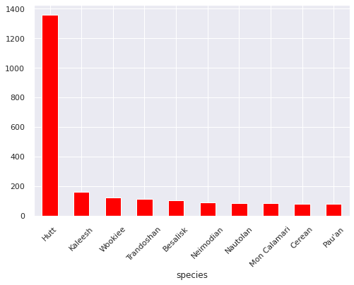

```python
#몸무게 상위 10개 종족
weight['mass'].sort_values(ascending=False).head(10).plot.bar(color='red')
plt.xticks(rotation=45)
plt.show()
```

[figure not shown]

```python
#스타워즈 종족별 몸무게 그래프 (sort=desc)
f, ax = plt.subplots(1, 1, figsize=(10, 8))

colors = sns.color_palette('crest',len(weight['mass']))

g = weight['mass'].sort_values(ascending=False).plot.bar(color = colors)
g.set_xticklabels(g.get_xticklabels(),rotation=90) #라벨 중첩 해소

plt.show()
```

### 4-5. 스타워즈 캐릭터의 무게-키 상관관계

```python
#Hutt - outlier
#몸무게 0 제외
out1 = sw['species'].isin(['Hutt'])
out2 = sw['mass'].isin([0])
sw[~out1][~out2].shape
```

```
(58, 11)
```

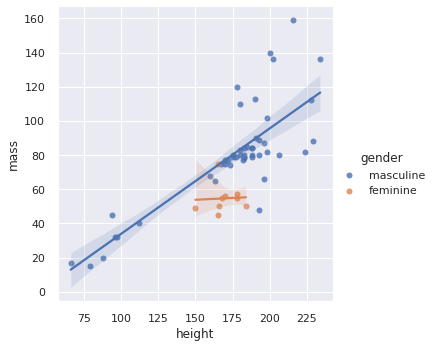

```python
#두 데이터 사이의 상관관계

sns.lmplot(data=sw[~out1][~out2], x='height', y='mass', hue='gender')
sns.set_style(style='darkgrid')

plt.show()
```

## 5.Review

[figure not shown]

### TAEWON KIM

Avid learner with diverse interests in coding, machine learning, artificial intelligence and reinforcement learning. 17+ years of experience working in multinational corporations.